# Assignment 1

This R Notebook provides a brief introduction to R Notebooks.

# Problem 1

1. Explore the overall structure of the dataset using “str” and “summary functions.

```r
realtor <- read.csv("realtor.csv", stringsAsFactors = FALSE)
str(realtor)
```

```
'data.frame':   923159 obs. of  12 variables:
 $ status      : chr  "for_sale" "for_sale" "for_sale" "for_sale" ...
 $ price       : num  105000 80000 67000 145000 65000 179000 50000 71600 100000 300000 ...
 $ bed         : num  3 4 2 4 6 4 3 3 2 5 ...
 $ bath        : num  2 2 1 2 2 3 1 2 1 3 ...
 $ acre_lot    : num  0.12 0.08 0.15 0.1 0.05 0.46 0.2 0.08 0.09 7.46 ...
 $ full_address: chr  "Sector Yahuecas Titulo # V84, Adjuntas, PR, 00601" "Km 78 9 Carr # 135, Adjuntas, PR, 00601" "556G 556-G 16 St, Juana Diaz, PR, 00795" "R5 Comunidad El Paraso Calle De Oro R-5 Ponce, Ponce, PR, 00731" ...
 $ street      : chr  "Sector Yahuecas Titulo # V84" "Km 78 9 Carr # 135" "556G 556-G 16 St" "R5 Comunidad El Paraso Calle De Oro R-5 Ponce" ...
 $ city        : chr  "Adjuntas" "Adjuntas" "Juana Diaz" "Ponce" ...
 $ state       : chr  "Puerto Rico" "Puerto Rico" "Puerto Rico" "Puerto Rico" ...
 $ zip_code    : num  601 601 795 731 680 612 639 731 730 670 ...
 $ house_size  : num  920 1527 748 1800 NA ...
 $ sold_date   : chr  "" "" "" "" ...
```

```r
summary(realtor)
```

```
    status              price                bed              bath           acre_lot         full_address          street
 Length:923159      Min.   :        0   Min.   :  1.00   Min.   :  1.00   Min.   :     0.00   Length:923159      Length:923159
 Class :character   1st Qu.:   269000   1st Qu.:  2.00   1st Qu.:  1.00   1st Qu.:     0.11   Class :character   Class :character
 Mode  :character   Median :   475000   Median :  3.00   Median :  2.00   Median :     0.29   Mode  :character   Mode  :character
                    Mean   :   884123   Mean   :  3.33   Mean   :  2.49   Mean   :    17.08
                    3rd Qu.:   839900   3rd Qu.:  4.00   3rd Qu.:  3.00   3rd Qu.:     1.15
                    Max.   :875000000   Max.   :123.00   Max.   :198.00   Max.   :100000.00
                    NA's   :71          NA's   :131703   NA's   :115192   NA's   :273623
     city              state              zip_code       house_size       sold_date
 Length:923159      Length:923159      Min.   :  601   Min.   :    100   Length:923159
 Class :character   Class :character   1st Qu.: 2919   1st Qu.:   1130   Class :character
 Mode  :character   Mode  :character   Median : 7004   Median :   1651   Mode  :character
                                       Mean   : 6590   Mean   :   2142
                                       3rd Qu.:10001   3rd Qu.:   2499
                                       Max.   :99999   Max.   :1450112
                                       NA's   :205     NA's   :297843
```

```r
names(realtor)
```

```
 [1] "status"       "price"        "bed"          "bath"         "acre_lot"     "full_address" "street"       "city"         "state"
[10] "zip_code"     "house_size"   "sold_date"
```

2. Find the type of each variable

status : Categorical variable and nominal

price: Numeric variable

bed: Numeric variable

bath: Numeric variable

acre_lot: Numeric variable

full_address: Categorical variable and nominal

street: Categorical variable and nominal

city: Categorical variable and nominal

city: Categorical variable and nominal

state: Categorical variable and nominal

zip_code: Categorical variable and nominal

sold_date: categorical and nominal

3. Remove duplicate observations

```r
unique(realtor)
```

|  | status | price | bed | bath | acre_lot | full_address | street | city | state | zip_code | house_size | sold_date |
| --- | --- | --- | --- | --- | --- | --- | --- | --- | --- | --- | --- | --- |
| 1 | for_sale | 105000 | 3 | 2 | 0.12 | Sector Yahuecas Titulo # V84, Adjuntas, PR, 00601 | Sector Yahuecas Titulo # V84 | Adjuntas | Puerto Rico | 601 | 920 |  |
| 2 | for_sale | 80000 | 4 | 2 | 0.08 | Km 78 9 Carr # 135, Adjuntas, PR, 00601 | Km 78 9 Carr # 135 | Adjuntas | Puerto Rico | 601 | 1527 |  |
| 3 | for_sale | 67000 | 2 | 1 | 0.15 | 556G 556-G 16 St, Juana Diaz, PR, 00795 | 556G 556-G 16 St | Juana Diaz | Puerto Rico | 795 | 748 |  |
| 4 | for_sale | 145000 | 4 | 2 | 0.10 | R5 Comunidad El Paraso Calle De Oro R-5 Ponce, Ponce, PR, 00731 | R5 Comunidad El Paraso Calle De Oro R-5 Ponce | Ponce | Puerto Rico | 731 | 1800 |  |
| 5 | for_sale | 65000 | 6 | 2 | 0.05 | 14 Navarro, Mayaguez, PR, 00680 | 14 Navarro | Mayaguez | Puerto Rico | 680 | NA |  |
| 6 | for_sale | 179000 | 4 | 3 | 0.46 | Bo Calabazas San Sebastian, San Sebastian, PR, 00612 | Bo Calabazas San Sebastian | San Sebastian | Puerto Rico | 612 | 2520 |  |
| 7 | for_sale | 50000 | 3 | 1 | 0.20 | 49.1 140, Ciales, PR, 00639 | 49.1 140 | Ciales | Puerto Rico | 639 | 2040 |  |
| 8 | for_sale | 71600 | 3 | 2 | 0.08 | 3467 St, Ponce, PR, 00731 | 3467 St | Ponce | Puerto Rico | 731 | 1050 |  |
| 9 | for_sale | 100000 | 2 | 1 | 0.09 | 230 Rio De Vida, Ponce, PR, 00730 | 230 Rio De Vida | Ponce | Puerto Rico | 730 | 1092 |  |
| 10 | for_sale | 300000 | 5 | 3 | 7.46 | Pr 120 Bo Maravilla Sur K M # 335, Las Marias, PR, 00670 | Pr 120 Bo Maravilla Sur K M # 335 | Las Marias | Puerto Rico | 670 | 5403 |  |

[output cut: 990 more lines]

```r
NA
```

4. Check for missing values

```r
#Shows the variables with missing values.
names(which(sapply(realtor, anyNA)))
```

```
[1] "price"      "bed"        "bath"       "acre_lot"   "zip_code"   "house_size"
```

5. Use IQR method to remove outliers in “price” variable

```r
IQR <- IQR(realtor$price, na.rm = TRUE)
IQR
```

```
[1] 570900
```

```r
Q <- quantile(realtor$price, probs=c(.25, .75), na.rm = TRUE)
Q
```

```
   25%    75%
269000 839900
```

```r
left <- 269000 - 1.5*IQR
right <- 839900 + 1.5*IQR
left
```

```
[1] -587350
```

```r
right
```

```
[1] 1696250
```

```r
price <- realtor$price
price_no_outliers <- subset(price,price > left & price < right)
price_no_outliers
```

```
   [1]  105000   80000   67000  145000   65000  179000   50000   71600  100000  300000   89000  150000  155000   79000  649000  120000  235000  105000
  [19]  575000  140000   50000  165000  189000  115000  122500  255000  425000   93000   75000  469000  189000  225000  495000  220000   70500  305000
  [37]  475000  195000  120000  650000  555000  400000  380000   95000   74000  139500  149900  180000  249000  252000  160000   90000  500000  339000
  [55]  265000  389000  575000   35000   58000   85000   47000  720000  375000   50000   39500  249500 1399000  600000  649000  189000  150000   74000
  [73]   65500   67500   74000  130000   95000  329000  130000   94770  150000  165000  215000   63000  215000  115000   99000  850000  140000  499000
  [91]  180000  225900  260000   31179  500000  225000   28000  425000  300000   75000  290000  550000  234900   44720   35000   75000   37000   37359
 [109]  739500   65000   56406  620000  649900   44995   37779   60123   38279  199900  125000  200000  150000 1000000  695000   98000   55000   75000
 [127]   80000  160000   46900  125000   95000  105000  330000  115000  285000  300000  155000  215000  115000  140000   87000  250000   70000  190000
 [145]  122500  575000  235000  150000  750000  125000  950000 1200000  495000   90000  395000   82000  389000  650000   45000   65000   80000  120000
 [163]   70000  400000  391000  160000  290000  835000  159000   79000  149900  140000  106000  165000  499000   79000  140000   46900   89000  155000
 [181]  125000  140000  115000   75000   70000  140000  165000  190000  215000   87000  450000  235000  575000  300000  305000  160000  225000  469000
 [199]  485000   90000  475000  620000  260000   82000  125000  339000  975000 1200000  950000  389000  650000  400000  950000  160000  349000  391000
 [217]  159000  835000   39900   29900  475000  200000   84900  148000   39500  220000   75000  110000  150000   69900   79000   65000  179000  145000
 [235]   79000  360000  179000   50000  134900   94600   59900  239000  279000  100000   89000  168000  150000   60000  140000   70000   80000  135000
 [253]  215000   42900   49900  138000  289000  132000  197000 1200000   67000   71600  100000   69900  185000   89000  200000  150000  200000  150000
```

[output cut: 42 more lines]

```r
new_price <- subset(price_no_outliers, price_no_outliers >= 50000)
summary(new_price)
```

```
   Min. 1st Qu.  Median    Mean 3rd Qu.    Max.
  50000  260000  439900  526229  699900 1695000
```

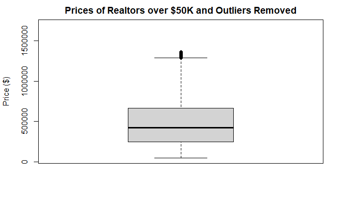

```r
new_price_IQR <- IQR(new_price)
new_left <- 260000 - 1.5*new_price_IQR
new_right <- 699900 + 1.5*new_price_IQR
new_price <- subset(new_price, new_price > new_left & new_price < new_right)
boxplot(new_price, main="Prices of Realtors over $50K and Outliers Removed", ylim= c(50000,1696250), ylab="Price ($)")
```

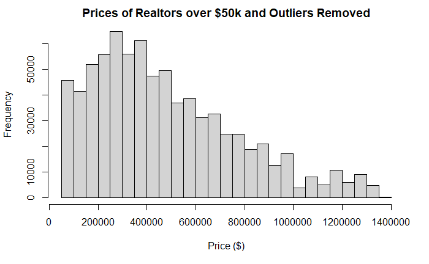

```r
hist(new_price, main="Prices of Realtors over $50k and Outliers Removed", xlab="Price ($)")
```

7.5 : Based on the boxplot and histogram, the price is positively skewed.

8. Percent of missing for price variable

```r
sum(is.na(realtor$price))
```

```
[1] 71
```

```r
percent_missing <- 71/length(new_price) * 100
percent_missing
```

```
[1] 0.009130224
```

9. Convert sold_date from character string to date/time, then create 2 attributes to store year and month.

```r
date_format <- as.Date(realtor$sold_date, format = "%Y -%m -%d")
class(date_format)
```

```
[1] "Date"
```

```r
sold_year <- as.Date(date_format, "%Y")
sold_month <- as.Date(date_format, "%m")
```

10/11. Convert “state” attribute to factor and take summary. Remove States with only one observation. Find if there is a statistical significant difference between average house price for different states.

Based on the boxplot, I beleive that there is a statistically significant difference between the average house price for different states. Using the one-way ANOVA test did not yield a p-value.

```r
new_realtor <- subset(realtor, realtor$price >= 50000)
new_realtor_no_outliers <- subset(new_realtor, new_realtor$price > new_left & new_realtor$price < new_right)
state <- factor(new_realtor_no_outliers$state)
summary(state)
```

```
   Connecticut       Delaware        Georgia          Maine  Massachusetts  New Hampshire     New Jersey       New York   Pennsylvania    Puerto Rico
         86145           2069             50          31166         141658          45759         216385         145514          16097          22281
  Rhode Island        Vermont Virgin Islands       Virginia  West Virginia        Wyoming
         28421          40023           2032             31              3              3
```

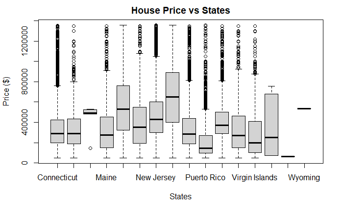

```r
boxplot(new_realtor_no_outliers$price~state, main="House Price vs States", xlab="States", ylab="Price ($)")
```

```r
oneway.test(new_price~state)
```

```
    One-way analysis of means (not assuming equal variances)

data:  new_price and state
F = NaN, num df = 15, denom df = NaN, p-value = NA
```

12: Find the correlation between house_price and variables sold_year, house_size, bed, and bath.

```r
attributes <- realtor[c("house_size", "bed", "bath")]
sold_year <- as.numeric(sold_year)
class(attributes)
```

```
[1] "data.frame"
```

```r
#correlation between house_size, bed, and bath to house_price
cor(realtor$price, attributes, use ="pairwise.complete.obs", method='spearman')
```

```
     house_size       bed      bath
[1,]  0.4372374 0.2436678 0.4900013
```

```r
#correlation between house price and sold_year
cor(realtor$price, sold_year, use ="pairwise.complete.obs", method = "spearman")
```

```
[1] -0.03449419
```

# Problem 2

13: Explore overall structure of dataset using “str” and “summary.

```r
airline <- read.csv("airline_satisfaction.csv", stringsAsFactors = FALSE)
str(airline)
```

```
'data.frame':   103904 obs. of  25 variables:
 $ X                                : int  0 1 2 3 4 5 6 7 8 9 ...
 $ id                               : int  70172 5047 110028 24026 119299 111157 82113 96462 79485 65725 ...
 $ Gender                           : chr  "Male" "Male" "Female" "Female" ...
 $ Customer.Type                    : chr  "Loyal Customer" "disloyal Customer" "Loyal Customer" "Loyal Customer" ...
 $ Age                              : int  13 25 26 25 61 26 47 52 41 20 ...
 $ Type.of.Travel                   : chr  "Personal Travel" "Business travel" "Business travel" "Business travel" ...
 $ Class                            : chr  "Eco Plus" "Business" "Business" "Business" ...
 $ Flight.Distance                  : int  460 235 1142 562 214 1180 1276 2035 853 1061 ...
 $ Inflight.wifi.service            : int  3 3 2 2 3 3 2 4 1 3 ...
 $ Departure.Arrival.time.convenient: int  4 2 2 5 3 4 4 3 2 3 ...
 $ Ease.of.Online.booking           : int  3 3 2 5 3 2 2 4 2 3 ...
 $ Gate.location                    : int  1 3 2 5 3 1 3 4 2 4 ...
 $ Food.and.drink                   : int  5 1 5 2 4 1 2 5 4 2 ...
 $ Online.boarding                  : int  3 3 5 2 5 2 2 5 3 3 ...
 $ Seat.comfort                     : int  5 1 5 2 5 1 2 5 3 3 ...
 $ Inflight.entertainment           : int  5 1 5 2 3 1 2 5 1 2 ...
 $ On.board.service                 : int  4 1 4 2 3 3 3 5 1 2 ...
 $ Leg.room.service                 : int  3 5 3 5 4 4 3 5 2 3 ...
 $ Baggage.handling                 : int  4 3 4 3 4 4 4 5 1 4 ...
 $ Checkin.service                  : int  4 1 4 1 3 4 3 4 4 4 ...
 $ Inflight.service                 : int  5 4 4 4 3 4 5 5 1 3 ...
 $ Cleanliness                      : int  5 1 5 2 3 1 2 4 2 2 ...
 $ Departure.Delay.in.Minutes       : int  25 1 0 11 0 0 9 4 0 0 ...
 $ Arrival.Delay.in.Minutes         : num  18 6 0 9 0 0 23 0 0 0 ...
 $ satisfaction                     : chr  "neutral or dissatisfied" "neutral or dissatisfied" "satisfied" "neutral or dissatisfied" ...
```

```r
summary(airline)
```

```
       X                id            Gender          Customer.Type           Age        Type.of.Travel        Class           Flight.Distance
 Min.   :     0   Min.   :     1   Length:103904      Length:103904      Min.   : 7.00   Length:103904      Length:103904      Min.   :  31
 1st Qu.: 25976   1st Qu.: 32534   Class :character   Class :character   1st Qu.:27.00   Class :character   Class :character   1st Qu.: 414
 Median : 51952   Median : 64857   Mode  :character   Mode  :character   Median :40.00   Mode  :character   Mode  :character   Median : 843
 Mean   : 51952   Mean   : 64924                                         Mean   :39.38                                         Mean   :1189
 3rd Qu.: 77927   3rd Qu.: 97368                                         3rd Qu.:51.00                                         3rd Qu.:1743
 Max.   :103903   Max.   :129880                                         Max.   :85.00                                         Max.   :4983

 Inflight.wifi.service Departure.Arrival.time.convenient Ease.of.Online.booking Gate.location   Food.and.drink  Online.boarding  Seat.comfort
 Min.   :0.00          Min.   :0.00                      Min.   :0.000          Min.   :0.000   Min.   :0.000   Min.   :0.00    Min.   :0.000
 1st Qu.:2.00          1st Qu.:2.00                      1st Qu.:2.000          1st Qu.:2.000   1st Qu.:2.000   1st Qu.:2.00    1st Qu.:2.000
 Median :3.00          Median :3.00                      Median :3.000          Median :3.000   Median :3.000   Median :3.00    Median :4.000
 Mean   :2.73          Mean   :3.06                      Mean   :2.757          Mean   :2.977   Mean   :3.202   Mean   :3.25    Mean   :3.439
 3rd Qu.:4.00          3rd Qu.:4.00                      3rd Qu.:4.000          3rd Qu.:4.000   3rd Qu.:4.000   3rd Qu.:4.00    3rd Qu.:5.000
 Max.   :5.00          Max.   :5.00                      Max.   :5.000          Max.   :5.000   Max.   :5.000   Max.   :5.00    Max.   :5.000

 Inflight.entertainment On.board.service Leg.room.service Baggage.handling Checkin.service Inflight.service  Cleanliness
 Min.   :0.000          Min.   :0.000    Min.   :0.000    Min.   :1.000    Min.   :0.000   Min.   :0.00     Min.   :0.000
 1st Qu.:2.000          1st Qu.:2.000    1st Qu.:2.000    1st Qu.:3.000    1st Qu.:3.000   1st Qu.:3.00     1st Qu.:2.000
 Median :4.000          Median :4.000    Median :4.000    Median :4.000    Median :3.000   Median :4.00     Median :3.000
 Mean   :3.358          Mean   :3.382    Mean   :3.351    Mean   :3.632    Mean   :3.304   Mean   :3.64     Mean   :3.286
 3rd Qu.:4.000          3rd Qu.:4.000    3rd Qu.:4.000    3rd Qu.:5.000    3rd Qu.:4.000   3rd Qu.:5.00     3rd Qu.:4.000
 Max.   :5.000          Max.   :5.000    Max.   :5.000    Max.   :5.000    Max.   :5.000   Max.   :5.00     Max.   :5.000

 Departure.Delay.in.Minutes Arrival.Delay.in.Minutes satisfaction
 Min.   :   0.00            Min.   :   0.00          Length:103904
 1st Qu.:   0.00            1st Qu.:   0.00          Class :character
 Median :   0.00            Median :   0.00          Mode  :character
 Mean   :  14.82            Mean   :  15.18
 3rd Qu.:  12.00            3rd Qu.:  13.00
 Max.   :1592.00            Max.   :1584.00
                            NA's   :310
```

14.What is the type of each variable categorical/discrete or numeric/continuous? For categorical/discrete variables, specify whether it is nominal or ordinal.

X : Numerical

id: Numerical

Gender: Categorical, and nominal

Customer.Type: Categorical, and nominal

Age: Numerical

Type.of.Travel: Categorical, and nominal

Class: Categorical, and nominal

Flight.Distance: Numerical

Inflight.wifi.service: Numerical

Departure.Arrival.time.convenient: Numerical

Ease.of.Online.booking: Numerical

Gate.location: Numerical

Food.and.drink: Numerical

Online.boarding: Numerical

Seat.comfort: Numerical

Inflight.entertainment: Numerical

On.board.service: Numerical

Leg.room.service: Numerical

Baggage.handling: Numerical

Checkin.service: Numerical

Inflight.service: Numerical

Cleanliness: Numerical

Departure.Delay.in.Minutes: Numerical

Arrival.Delay.in.Minutes: Numerical

satisfaction: Categorical, and Nominal

15. Does any of the variables have missing values? Which ones?

```r
names(which(sapply(airline, anyNA)))
```

```
[1] "Arrival.Delay.in.Minutes"
```

16: Remove the “id” and “X” variables

```r
airline = subset(airline, select =-c(id,X))
summary(airline)
```

```
    Gender          Customer.Type           Age        Type.of.Travel        Class           Flight.Distance Inflight.wifi.service
 Length:103904      Length:103904      Min.   : 7.00   Length:103904      Length:103904      Min.   :  31    Min.   :0.00
 Class :character   Class :character   1st Qu.:27.00   Class :character   Class :character   1st Qu.: 414    1st Qu.:2.00
 Mode  :character   Mode  :character   Median :40.00   Mode  :character   Mode  :character   Median : 843    Median :3.00
                                       Mean   :39.38                                         Mean   :1189    Mean   :2.73
                                       3rd Qu.:51.00                                         3rd Qu.:1743    3rd Qu.:4.00
                                       Max.   :85.00                                         Max.   :4983    Max.   :5.00

 Departure.Arrival.time.convenient Ease.of.Online.booking Gate.location   Food.and.drink  Online.boarding  Seat.comfort   Inflight.entertainment
 Min.   :0.00                      Min.   :0.000          Min.   :0.000   Min.   :0.000   Min.   :0.00    Min.   :0.000   Min.   :0.000
 1st Qu.:2.00                      1st Qu.:2.000          1st Qu.:2.000   1st Qu.:2.000   1st Qu.:2.00    1st Qu.:2.000   1st Qu.:2.000
 Median :3.00                      Median :3.000          Median :3.000   Median :3.000   Median :3.00    Median :4.000   Median :4.000
 Mean   :3.06                      Mean   :2.757          Mean   :2.977   Mean   :3.202   Mean   :3.25    Mean   :3.439   Mean   :3.358
 3rd Qu.:4.00                      3rd Qu.:4.000          3rd Qu.:4.000   3rd Qu.:4.000   3rd Qu.:4.00    3rd Qu.:5.000   3rd Qu.:4.000
 Max.   :5.00                      Max.   :5.000          Max.   :5.000   Max.   :5.000   Max.   :5.00    Max.   :5.000   Max.   :5.000

 On.board.service Leg.room.service Baggage.handling Checkin.service Inflight.service  Cleanliness    Departure.Delay.in.Minutes
 Min.   :0.000    Min.   :0.000    Min.   :1.000    Min.   :0.000   Min.   :0.00     Min.   :0.000   Min.   :   0.00
 1st Qu.:2.000    1st Qu.:2.000    1st Qu.:3.000    1st Qu.:3.000   1st Qu.:3.00     1st Qu.:2.000   1st Qu.:   0.00
 Median :4.000    Median :4.000    Median :4.000    Median :3.000   Median :4.00     Median :3.000   Median :   0.00
 Mean   :3.382    Mean   :3.351    Mean   :3.632    Mean   :3.304   Mean   :3.64     Mean   :3.286   Mean   :  14.82
 3rd Qu.:4.000    3rd Qu.:4.000    3rd Qu.:5.000    3rd Qu.:4.000   3rd Qu.:5.00     3rd Qu.:4.000   3rd Qu.:  12.00
 Max.   :5.000    Max.   :5.000    Max.   :5.000    Max.   :5.000   Max.   :5.00     Max.   :5.000   Max.   :1592.00

 Arrival.Delay.in.Minutes satisfaction
 Min.   :   0.00          Length:103904
 1st Qu.:   0.00          Class :character
 Median :   0.00          Mode  :character
 Mean   :  15.18
 3rd Qu.:  13.00
 Max.   :1584.00
 NA's   :310
```

17: Is there an association between “satisfaction” and any of the other attributes in the dataset? Use appropriate plots and statistic tests to answer this question.

```r
library(gmodels)
sat_Gender_table <- table(airline$Gender,airline$satisfaction)
chisq.test(sat_Gender_table)
```

```
    Pearson's Chi-squared test with Yates' continuity correction

data:  sat_Gender_table
X-squared = 15.444, df = 1, p-value = 8.497e-05
```

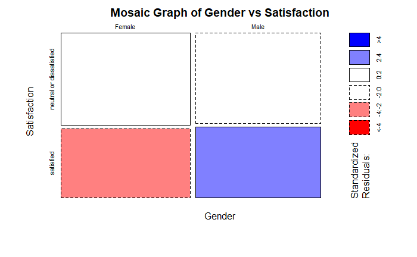

```r
mosaicplot(sat_Gender_table, ylab="Satisfaction", xlab="Gender", main ="Mosaic Graph of Gender vs Satisfaction", shade =TRUE)
```

```r
NA
NA
NA
```

Using a Chi-square test and mosaic plot between satisfaction and Gender and having a very low p-value indicates an association between satisfaction and gender.

```r
sat_cust_table <- table(airline$Customer.Type, airline$satisfaction)
chisq.test(sat_cust_table)
```

```
    Pearson's Chi-squared test with Yates' continuity correction

data:  sat_cust_table
X-squared = 3657.3, df = 1, p-value < 2.2e-16
```

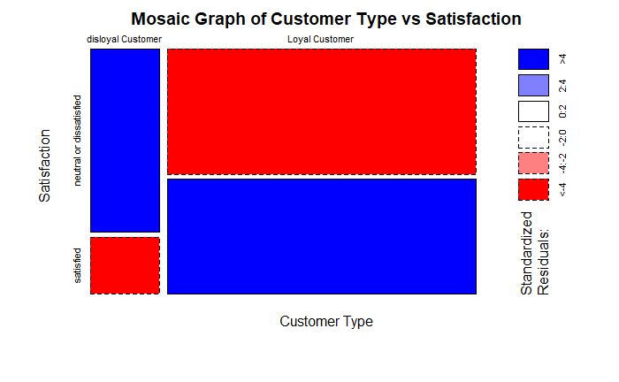

```r
mosaicplot(sat_cust_table, ylab="Satisfaction", xlab="Customer Type", main ="Mosaic Graph of Customer Type vs Satisfaction", shade =TRUE)
```

Using a Chi-square test and mosaic plot between satisfaction and customer type, there appears to be an association between the two.

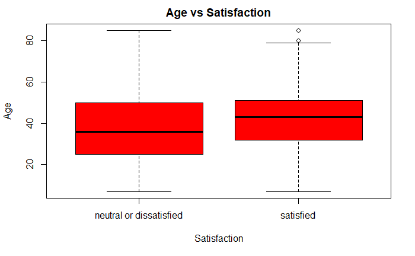

```r
boxplot(Age~satisfaction, main="Age vs Satisfaction", xlab="Satisfaction", ylab="Age", col="red")
```

```r
oneway.test(Age~satisfaction, data = airline)
```

```
    One-way analysis of means (not assuming equal variances)

data:  Age and satisfaction
F = 2129, num df = 1, denom df = 103881, p-value < 2.2e-16
```

Using a Side by Side Boxplot and one-way test, we see that there is an association between Age and satisfaction.

```r
sat_Travel_Table <- table(airline$Type.of.Travel, airline$satisfaction)
chisq.test(sat_Travel_Table)
```

```
    Pearson's Chi-squared test with Yates' continuity correction

data:  sat_Travel_Table
X-squared = 20945, df = 1, p-value < 2.2e-16
```

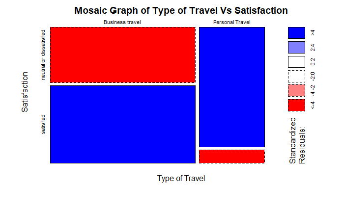

```r
mosaicplot(sat_Travel_Table, ylab="Satisfaction", xlab="Type of Travel", main="Mosaic Graph of Type of Travel Vs Satisfaction", shade = TRUE)
```

Given the Chi-square test and mosaic plot, there appears to be an association with type of travel and satisfaction.

```r
sat_Class_table <- table(airline$Class, airline$satisfaction)
chisq.test(sat_Class_table)
```

```
    Pearson's Chi-squared test

data:  sat_Class_table
X-squared = 26472, df = 2, p-value < 2.2e-16
```

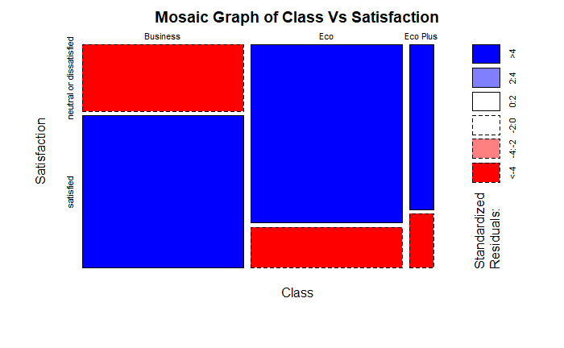

```r
mosaicplot(sat_Class_table, ylab="Satisfaction", xlab="Class", main="Mosaic Graph of Class Vs Satisfaction", shade =TRUE)
```

Using chi-square and mosaic plot, there appears to be an association with class and satisfaction.

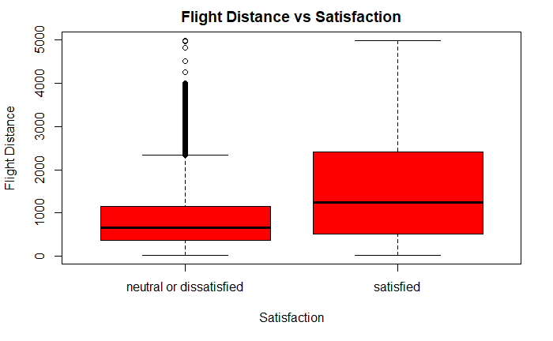

```r
boxplot(Flight.Distance~satisfaction, main="Flight Distance vs Satisfaction", xlab="Satisfaction", ylab="Flight Distance", col="red")
```

```r
t.test(Flight.Distance~satisfaction)
```

```
    Welch Two Sample t-test

data:  Flight.Distance by satisfaction
t = -96.424, df = 76889, p-value < 2.2e-16
alternative hypothesis: true difference in means between group neutral or dissatisfied and group satisfied is not equal to 0
95 percent confidence interval:
 -613.4412 -588.9993
sample estimates:
mean in group neutral or dissatisfied               mean in group satisfied
                               928.92                               1530.14
```

Using side by side boxplots and t-test, there appears to be an association with flight distance and satisfaction

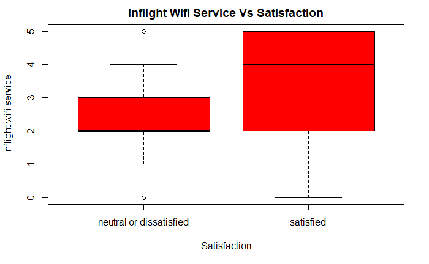

```r
boxplot(Inflight.wifi.service~satisfaction, main="Inflight Wifi Service Vs Satisfaction", xlab="Satisfaction", ylab="Inflight wifi service", col="red")
```

```r
t.test(Inflight.wifi.service~satisfaction)
```

```
    Welch Two Sample t-test

data:  Inflight.wifi.service by satisfaction
t = -89.855, df = 69737, p-value < 2.2e-16
alternative hypothesis: true difference in means between group neutral or dissatisfied and group satisfied is not equal to 0
95 percent confidence interval:
 -0.7782690 -0.7450411
sample estimates:
mean in group neutral or dissatisfied               mean in group satisfied
                             2.399633                              3.161288
```

Using side by side boxplots and t-test, there appears to ba an association with inflight wifi service and satisfaction.

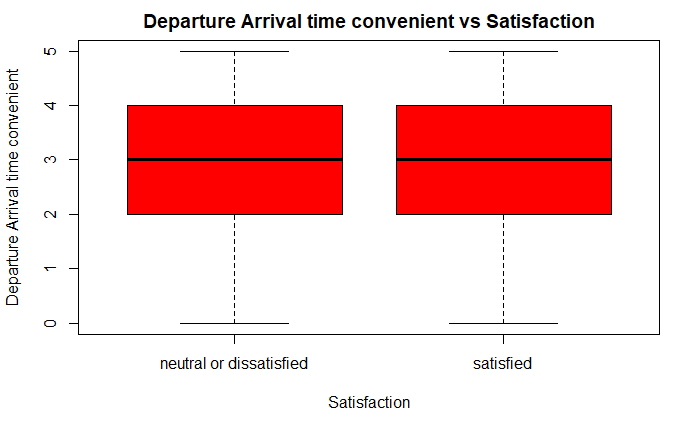

```r
boxplot(Departure.Arrival.time.convenient~satisfaction, main="Departure Arrival time convenient vs Satisfaction", xlab="Satisfaction", ylab="Departure Arrival time convenient", col="red")
```

```r
t.test(Departure.Arrival.time.convenient~satisfaction)
```

```
    Welch Two Sample t-test

data:  Departure.Arrival.time.convenient by satisfaction
t = 16.58, df = 95187, p-value < 2.2e-16
alternative hypothesis: true difference in means between group neutral or dissatisfied and group satisfied is not equal to 0
95 percent confidence interval:
 0.1400334 0.1775803
sample estimates:
mean in group neutral or dissatisfied               mean in group satisfied
                             3.129112                              2.970305
```

Using side by side boxplot and t-test, there appears to be an association with Departure Arrival time convenient and satisfaction.

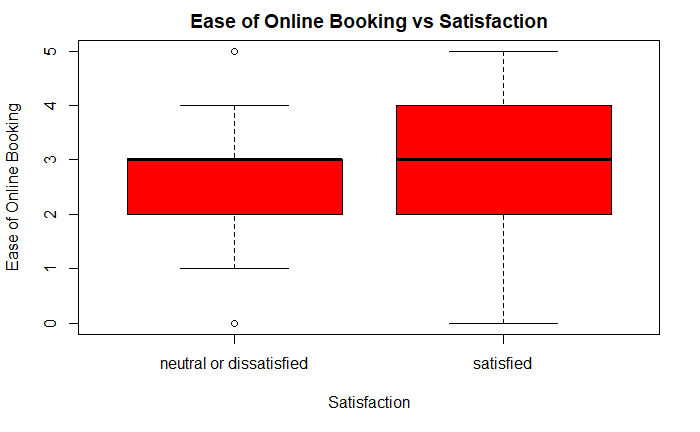

```r
boxplot(Ease.of.Online.booking~satisfaction, main="Ease of Online Booking vs Satisfaction", xlab="Satisfaction", ylab = "Ease of Online Booking", col="red")
```

```r
t.test(Ease.of.Online.booking~satisfaction)
```

```
    Welch Two Sample t-test

data:  Ease.of.Online.booking by satisfaction
t = -54.259, df = 81846, p-value < 2.2e-16
alternative hypothesis: true difference in means between group neutral or dissatisfied and group satisfied is not equal to 0
95 percent confidence interval:
 -0.5022422 -0.4672221
sample estimates:
mean in group neutral or dissatisfied               mean in group satisfied
                             2.546850                              3.031582
```

Based on the side by side boxplot and t-test, there appears to be an association with ease of online booking and satisfaction.

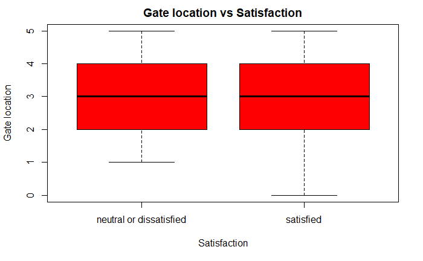

```r
boxplot(Gate.location~satisfaction, main="Gate location vs Satisfaction", xlab="Satisfaction", ylab="Gate location", col="red")
```

```r
t.test(Gate.location~satisfaction)
```

```
    Welch Two Sample t-test

data:  Gate.location by satisfaction
t = -0.21589, df = 89481, p-value = 0.8291
alternative hypothesis: true difference in means between group neutral or dissatisfied and group satisfied is not equal to 0
95 percent confidence interval:
 -0.01772247  0.01420559
sample estimates:
mean in group neutral or dissatisfied               mean in group satisfied
                             2.976121                              2.977879
```

Based on the t-test and side by side boxplot, there seems to not be an association with gate location and satisfaction.

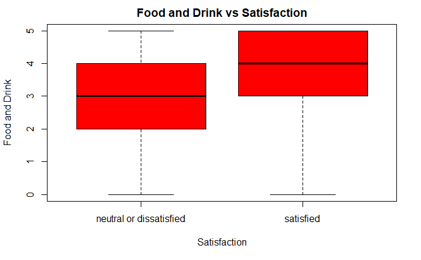

```r
boxplot(Food.and.drink~satisfaction, main="Food and Drink vs Satisfaction", xlab="Satisfaction", ylab = "Food and Drink", col="red")
```

```r
t.test(Food.and.drink~satisfaction)
```

```
    Welch Two Sample t-test

data:  Food.and.drink by satisfaction
t = -70.005, df = 100517, p-value < 2.2e-16
alternative hypothesis: true difference in means between group neutral or dissatisfied and group satisfied is not equal to 0
95 percent confidence interval:
 -0.5790309 -0.5474908
sample estimates:
mean in group neutral or dissatisfied               mean in group satisfied
                              2.95805                               3.52131
```

Based on the side by side boxlplots and t-test, there appears to be an association with food and drink and satisfaction.

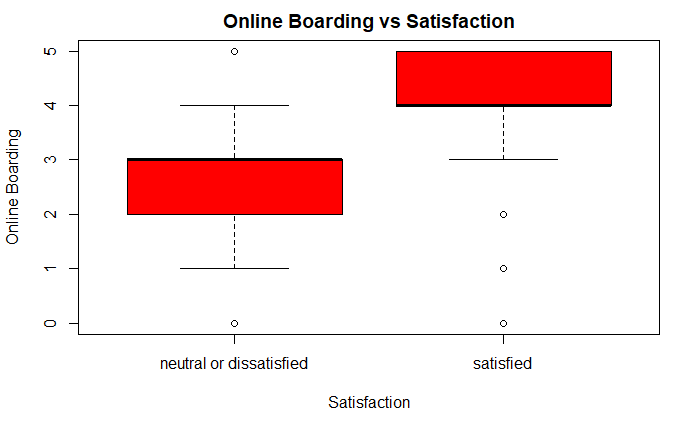

```r
boxplot(Online.boarding~satisfaction, main="Online Boarding vs Satisfaction", xlab="Satisfaction", ylab = "Online Boarding", col="red")
```

```r
t.test(Online.boarding~satisfaction)
```

```
    Welch Two Sample t-test

data:  Online.boarding by satisfaction
t = -186.9, df = 94920, p-value < 2.2e-16
alternative hypothesis: true difference in means between group neutral or dissatisfied and group satisfied is not equal to 0
95 percent confidence interval:
 -1.385730 -1.356967
sample estimates:
mean in group neutral or dissatisfied               mean in group satisfied
                             2.656125                              4.027474
```

Based on the side by side boxplots and t-test, there appears to be an association with online boarding and satisfaction.

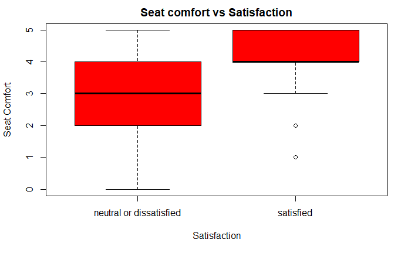

```r
boxplot(Seat.comfort~satisfaction, main="Seat comfort vs Satisfaction", xlab="Satisfaction", ylab = "Seat Comfort", col="red")
```

```r
t.test(Seat.comfort~satisfaction)
```

```
    Welch Two Sample t-test

data:  Seat.comfort by satisfaction
t = -122.35, df = 101994, p-value < 2.2e-16
alternative hypothesis: true difference in means between group neutral or dissatisfied and group satisfied is not equal to 0
95 percent confidence interval:
 -0.9451374 -0.9153324
sample estimates:
mean in group neutral or dissatisfied               mean in group satisfied
                             3.036295                              3.966530
```

Based on the Side by side boxplots and t-test, there appears to be an association with seat comfort and satisfaction.

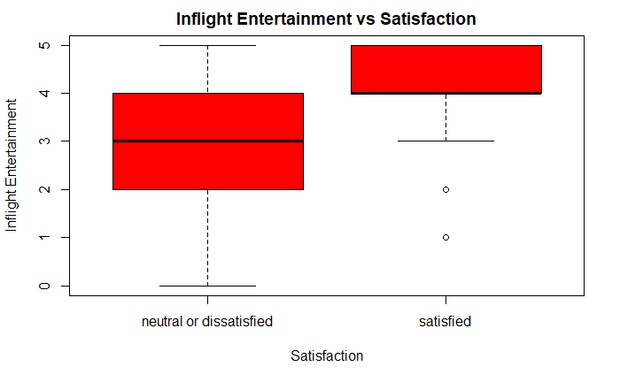

```r
boxplot(Inflight.entertainment~satisfaction, main="Inflight Entertainment vs Satisfaction", xlab="Satisfaction", ylab = "Inflight Entertainment", col="red")
```

```r
t.test(Inflight.entertainment~satisfaction)
```

```
    Welch Two Sample t-test

data:  Inflight.entertainment by satisfaction
t = -143.71, df = 103506, p-value < 2.2e-16
alternative hypothesis: true difference in means between group neutral or dissatisfied and group satisfied is not equal to 0
95 percent confidence interval:
 -1.085378 -1.056172
sample estimates:
mean in group neutral or dissatisfied               mean in group satisfied
                             2.894156                              3.964931
```

From the side by side boxplots and t-test, there appears to be an association with inflight entertainment and satisfaction.

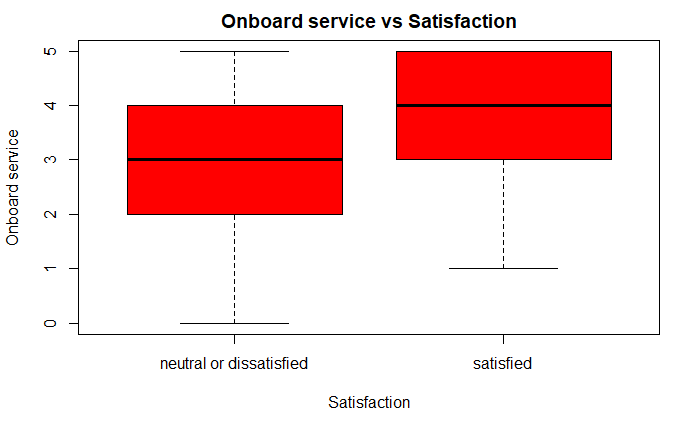

```r
boxplot(On.board.service~satisfaction, main="Onboard service vs Satisfaction", xlab="Satisfaction", ylab = "Onboard service", col="red")
```

```r
t.test(On.board.service~satisfaction)
```

```
    Welch Two Sample t-test

data:  On.board.service by satisfaction
t = -111.71, df = 101988, p-value < 2.2e-16
alternative hypothesis: true difference in means between group neutral or dissatisfied and group satisfied is not equal to 0
95 percent confidence interval:
 -0.8528715 -0.8234600
sample estimates:
mean in group neutral or dissatisfied               mean in group satisfied
                             3.019158                              3.857324
```

Side by side boxplots and t-test show an association with onboard service and satisfaction.

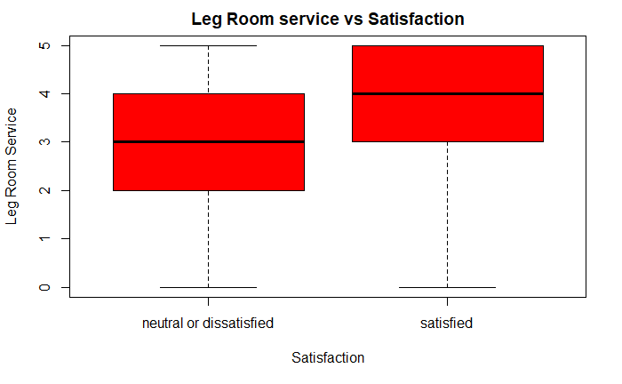

```r
boxplot(Leg.room.service~satisfaction, main="Leg Room service vs Satisfaction", xlab="Satisfaction", ylab = "Leg Room Service", col="red")
```

```r
t.test(Leg.room.service~satisfaction)
```

```
    Welch Two Sample t-test

data:  Leg.room.service by satisfaction
t = -107.74, df = 101120, p-value < 2.2e-16
alternative hypothesis: true difference in means between group neutral or dissatisfied and group satisfied is not equal to 0
95 percent confidence interval:
 -0.8464544 -0.8162088
sample estimates:
mean in group neutral or dissatisfied               mean in group satisfied
                             2.990812                              3.822143
```

Side by side boxplots and t-test show an association with leg room service and satisfaction.

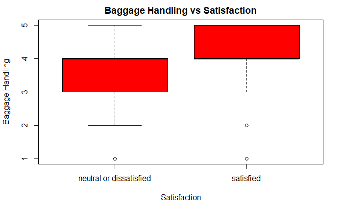

```r
boxplot(Baggage.handling~satisfaction, main="Baggage Handling vs Satisfaction", xlab="Satisfaction", ylab = "Baggage Handling", col="red")
```

```r
t.test(Baggage.handling~satisfaction)
```

```
    Welch Two Sample t-test

data:  Baggage.handling by satisfaction
t = -83.178, df = 99861, p-value < 2.2e-16
alternative hypothesis: true difference in means between group neutral or dissatisfied and group satisfied is not equal to 0
95 percent confidence interval:
 -0.6043171 -0.5764929
sample estimates:
mean in group neutral or dissatisfied               mean in group satisfied
                             3.375991                              3.966396
```

Side by side boxplots and t-test show an association with baggage handling and satisfaction.

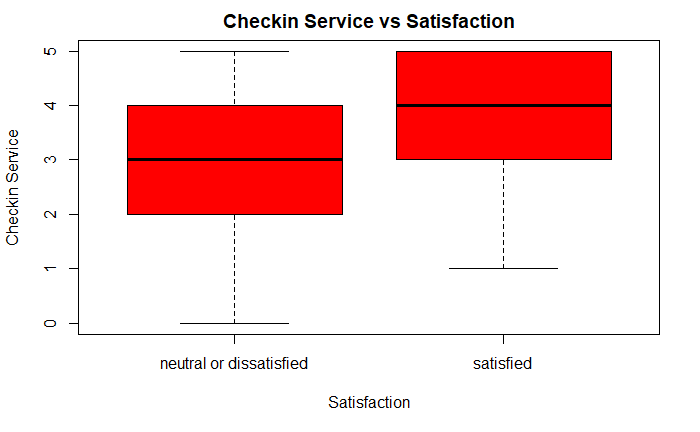

```r
boxplot(Checkin.service~satisfaction, main="Checkin Service vs Satisfaction", xlab="Satisfaction", ylab = "Checkin Service", col="red")
```

```r
t.test(Checkin.service~satisfaction)
```

```
    Welch Two Sample t-test

data:  Checkin.service by satisfaction
t = -79.397, df = 101033, p-value < 2.2e-16
alternative hypothesis: true difference in means between group neutral or dissatisfied and group satisfied is not equal to 0
95 percent confidence interval:
 -0.6179764 -0.5882008
sample estimates:
mean in group neutral or dissatisfied               mean in group satisfied
                             3.042952                              3.646041
```

Side by side boxplots and t-test show an association with checkin service and satisfaction.

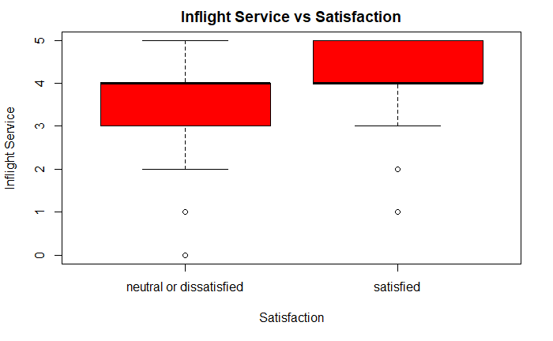

```r
boxplot(Inflight.service~satisfaction, main="Inflight Service vs Satisfaction", xlab="Satisfaction", ylab = "Inflight Service", col="red")
```

```r
t.test(Inflight.service~satisfaction)
```

```
    Welch Two Sample t-test

data:  Inflight.service by satisfaction
t = -82.172, df = 100100, p-value < 2.2e-16
alternative hypothesis: true difference in means between group neutral or dissatisfied and group satisfied is not equal to 0
95 percent confidence interval:
 -0.5944969 -0.5667973
sample estimates:
mean in group neutral or dissatisfied               mean in group satisfied
                             3.388814                              3.969461
```

Side by side boxplots and t-test show an association with inflight service and satisfaction.

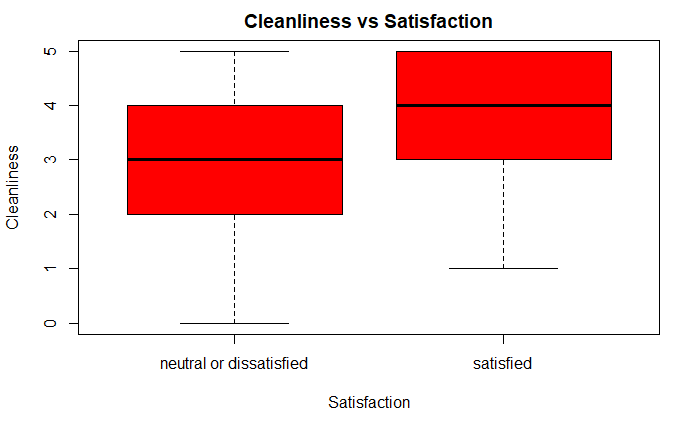

```r
boxplot(Cleanliness~satisfaction, main="Cleanliness vs Satisfaction", xlab="Satisfaction", ylab = "Cleanliness", col="red")
```

```r
t.test(Cleanliness~satisfaction)
```

```
    Welch Two Sample t-test

data:  Cleanliness by satisfaction
t = -105.37, df = 102441, p-value < 2.2e-16
alternative hypothesis: true difference in means between group neutral or dissatisfied and group satisfied is not equal to 0
95 percent confidence interval:
 -0.8232531 -0.7931845
sample estimates:
mean in group neutral or dissatisfied               mean in group satisfied
                             2.936123                              3.744342
```

Side by side boxplots and t-test show an association with cleanliness and satisfaction.

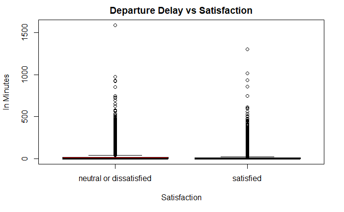

```r
boxplot(Departure.Delay.in.Minutes~satisfaction, main="Departure Delay vs Satisfaction", xlab="Satisfaction", ylab = "In Minutes", col="red")
```

```r
t.test(Departure.Delay.in.Minutes~satisfaction)
```

```
    Welch Two Sample t-test

data:  Departure.Delay.in.Minutes by satisfaction
t = 16.575, df = 101869, p-value < 2.2e-16
alternative hypothesis: true difference in means between group neutral or dissatisfied and group satisfied is not equal to 0
95 percent confidence interval:
 3.434980 4.356307
sample estimates:
mean in group neutral or dissatisfied               mean in group satisfied
                             16.50373                              12.60808
```

Side by side boxplot is harder to see, but using the t-test, we see an association with Departure Delay in minutes and satisfaction.

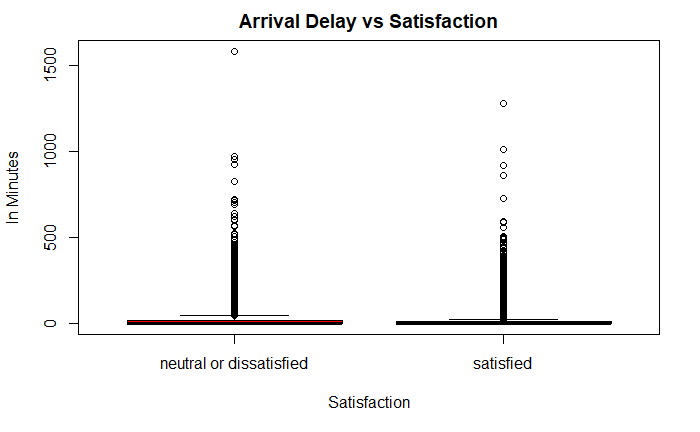

```r
boxplot(Arrival.Delay.in.Minutes~satisfaction, main="Arrival Delay vs Satisfaction", xlab="Satisfaction", ylab = "In Minutes", col="red")
```

```r
t.test(Arrival.Delay.in.Minutes~satisfaction)
```

```
    Welch Two Sample t-test

data:  Arrival.Delay.in.Minutes by satisfaction
t = 18.862, df = 101365, p-value < 2.2e-16
alternative hypothesis: true difference in means between group neutral or dissatisfied and group satisfied is not equal to 0
95 percent confidence interval:
 4.029483 4.963990
sample estimates:
mean in group neutral or dissatisfied               mean in group satisfied
                             17.12754                              12.63080
```

While it is difficult to see the side by side boxplot, using the t-test we see an association with arrival delay in minutes and satisfaction.